# 2018 College Football Playoff Ticket Option Pricing

10/19/2018

## Some Background

- College Football Playoff (CFP) - a 4 team bracket - started with 2014-15 season.
- In 2018 CFP partnered with OptionIt to initiate a RSVP system for the National Championship Game (and other major bowl games).
- An RSVP is an **option** - the right (but not an obligation) to buy a ticket for face value, IF your team makes it.
- Costs (and savings) are high. E.g. for #1-ranked Alabama
  - An option for a lower-level seat for is nearly $600.
  - With the added face value of roughly $800, total cost would be $1,400.
  - While not cheap, this is likely less than the ticket would cost in the secondary market the week before the game.

## Questions of Possible Interest

1. Before the season begins, would knowing a team’s performance during the previous year drive prices?
2. Would initial preseason ranking have any influence on prices?
3. After the start of the season, would the following affect prices (and volatility)?
   - rankings
   - performance
   - strength of schedule
   - injuries
   - other variables

## Previous Year-end Rank & Early Prices

- Using Massey’s year-end rankings and early option prices (February 2018) we see:
  - Ranking at end of previous season does *generally* appear to inform price.
  - Some teams started out higher than what might be expected.

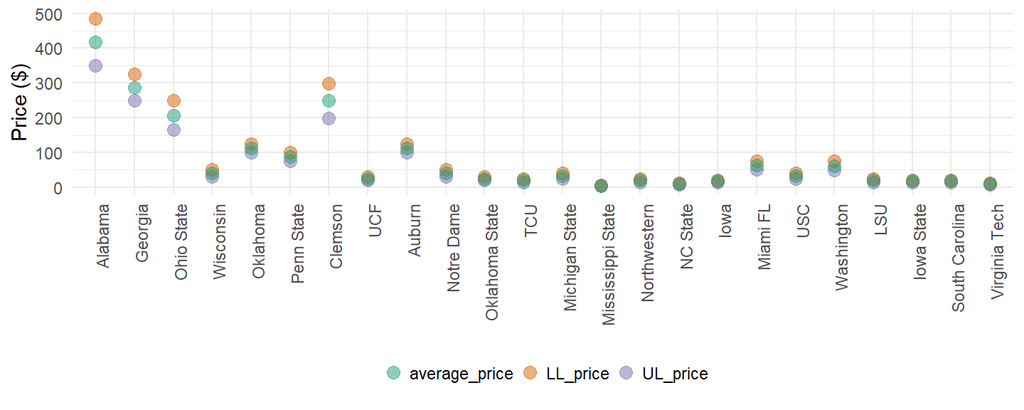

## Ranking Correlations

- An exploration of the correlation of well-known rankings was conducted. As expected, there is strong correlation.
- Going forward, we use the mean ranking for each team among this set.

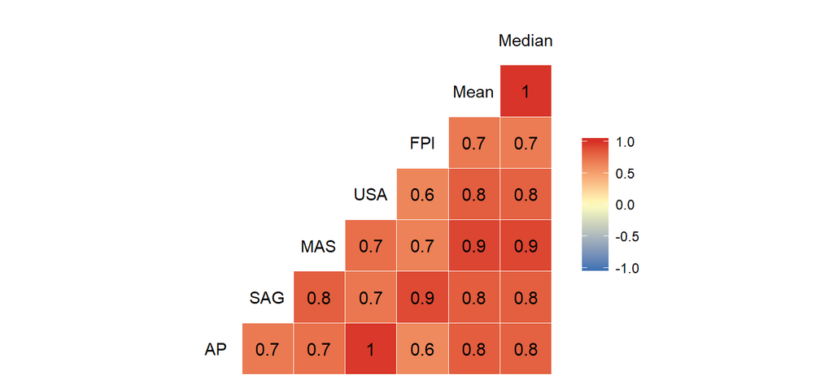

## Top 10 Trends

- The following figure shows the price trend for every team that has been in the AP top 10 since the beginning of the season.
- Quick visual inspection suggests persistent high confidence for Alabama, Ohio State, and Clemson. In recent weeks, Notre Dame has noticeably increased while Georgia dropped.

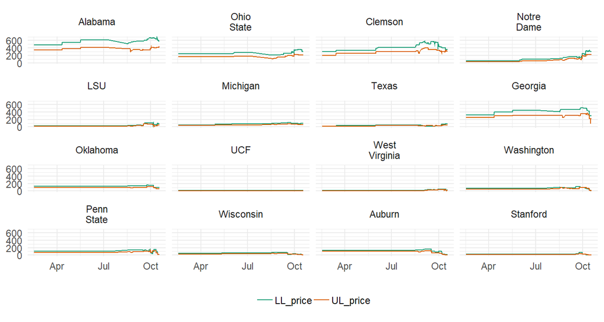

## Volatility

- In financial option pricing, volatility is usually a key factor affecting price.
- Some schools (Oregon, Wash St, Oklahoma St, USC) have *much* higher volatility than most.

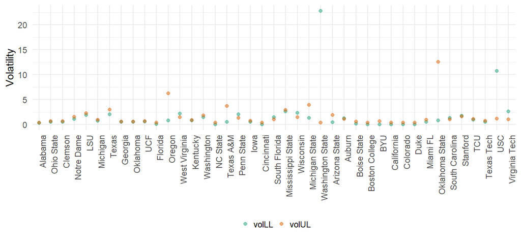

## Explaining Volatility (for Lower Level)

- Using generalized additive models to be as flexible as possible; all parameters but wins are smoothed.

| term | edf | ref.df | statistic | p.value |
| --- | --- | --- | --- | --- |
| s(Mean) | 4.161214 | 5.138267 | 1.1080694 | 0.3714927 |
| s(n) | 1.000000 | 1.000000 | 0.0017288 | 0.9669246 |
| s(masseySoS) | 1.000000 | 1.000000 | 0.0552506 | 0.8146898 |

| term | estimate | std.error | statistic | p.value |
| --- | --- | --- | --- | --- |
| (Intercept) | 1.0205476 | 1.9867907 | 0.5136664 | 0.6087189 |
| wins | -0.0499556 | 0.5584108 | -0.0894602 | 0.9289110 |

## Explaining Volatility (cont.)

- Effects of ranking and injuries on volatility seen earlier in season appear to have gone away.

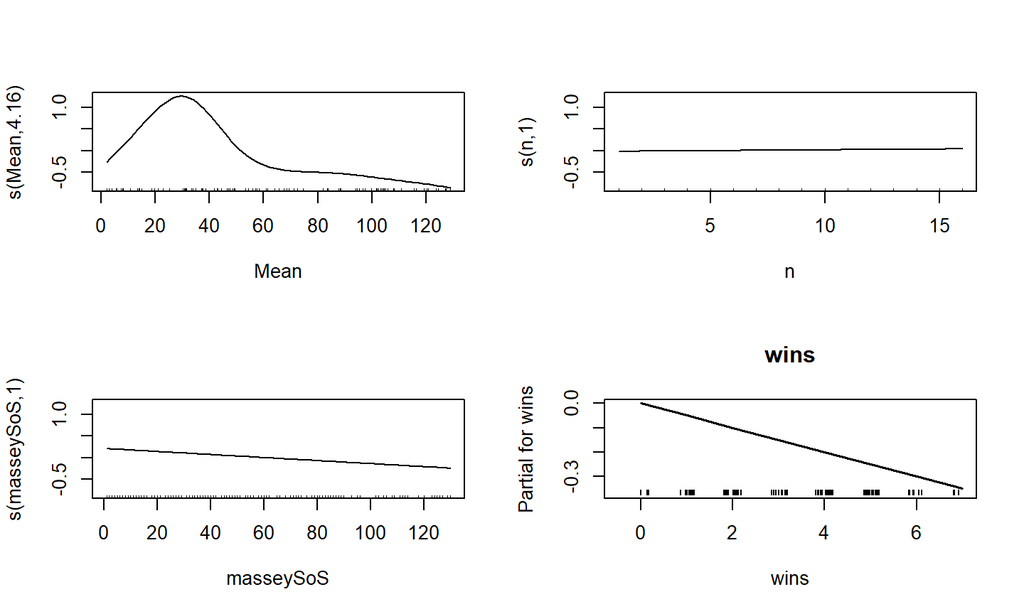

## Explaining Current Prices

We will run a similar model, except using current lower level price as our outcome variable.

| term | edf | ref.df | statistic | p.value |
| --- | --- | --- | --- | --- |
| s(Mean) | 8.665056 | 8.964891 | 33.0153834 | 0.0000000 |
| s(n) | 1.000000 | 1.000000 | 0.0038378 | 0.9507468 |
| s(masseySoS) | 2.393230 | 2.964421 | 0.8881627 | 0.5070527 |

| term | estimate | std.error | statistic | p.value |
| --- | --- | --- | --- | --- |
| (Intercept) | 15.101440 | 32.382888 | 0.4663401 | 0.6421520 |
| wins | 3.575966 | 9.114269 | 0.3923481 | 0.6957724 |

## Explaining Current Prices (cont.)

- Mean ranking appears to offer only significant explanatory power for price.

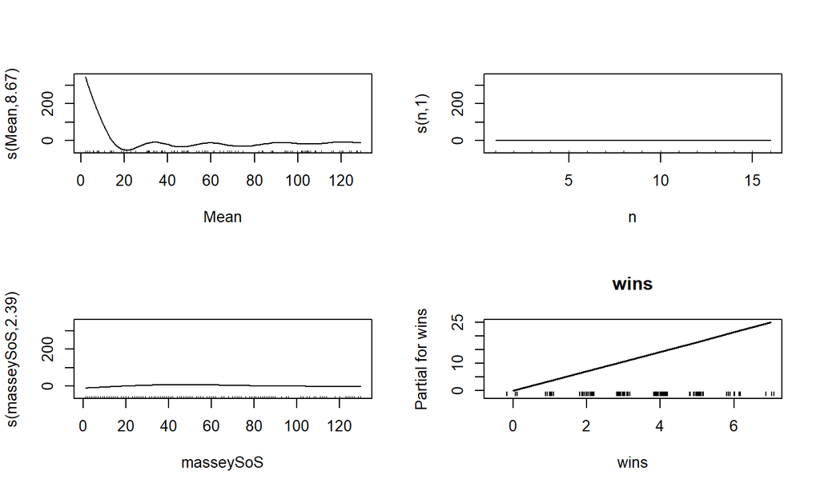

## Take Away Messages

- The models presented here are incomplete, as we are only halfway into the college football season.
- We are encouraged that the ticket options are behaving in a predictable manner.
- Our goal is to be able to use these models next season to buy before a team becomes the hot dark horse and sell before a team’s dreams burn in flames.
- The **general strategy** is clear: buy early and buy towards the top of the projected rankings.